# ASAD Assignment

Rajesh Sinha (2016TC12033@wilp.bits-pilani.ac.in)

21 September 2017

Before we start anything, set a seed to the pseudo-random number generator so that our work is reproducible

```r
library(ggplot2)
set.seed(100000)
```

# Question-1 : Implement Linear and Polynomial Regression for a Chosen Data Set

We are going to be using **Skin Cancer Index data set** in this response. This response has been knitted in R Markdown to HTML document.

## Reading the dataset

First we read the dataset from file assumed to be present in current directory. Then we analyze if to see whether it has any missing values or not.

```r
library(ggplot2)
setwd("~/")
df <- read.csv(file = "./SkinCancer.csv", header = TRUE, sep = ",")
```

Lets check the data read and confirm how many rows and columns have been read and a sneak peak at data

```r
dim(df) # No of rows and columns
```

```
## [1] 1000    3
```

```r
head(df) # first few lines
```

```
##   Exp.to.sun Usage.sun.screen.lotion Skin.cancer.index
## 1       1649                    3419              1397
## 2       1873                    3551              2295
## 3       1392                    3025               912
## 4       1588                    3225              1497
## 5       1591                    3266              1412
## 6       2086                    4560              1295
```

```r
summary(df) # column wise summaries
```

```
##    Exp.to.sun   Usage.sun.screen.lotion Skin.cancer.index
##  Min.   : 651   Min.   :1542            Min.   :  52
##  1st Qu.:1761   1st Qu.:3750            1st Qu.:1259
##  Median :2058   Median :4319            Median :1632
##  Mean   :2061   Mean   :4329            Mean   :1658
##  3rd Qu.:2344   3rd Qu.:4932            3rd Qu.:2072
##  Max.   :3635   Max.   :7346            Max.   :3518
```

Lets check and see if there are any missing values before we start the regression exercise

```r
sum(complete.cases(df)) == nrow(df) #is the no of complete rows same as rows of data frame
```

```
## [1] TRUE
```

and some plots just to see how they look when compared individually

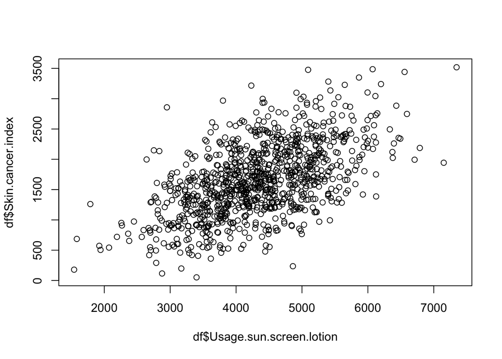

```r
plot(df$Usage.sun.screen.lotion, df$Skin.cancer.index)
```

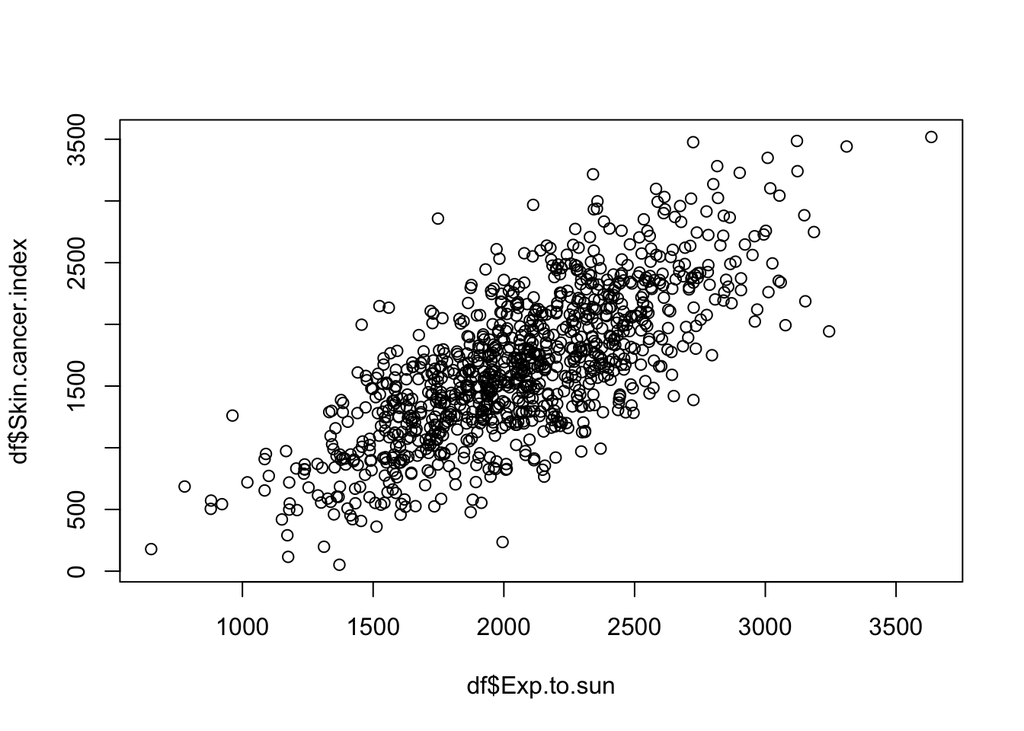

```r
plot(df$Exp.to.sun, df$Skin.cancer.index)
```

and correlations

```r
cor(df$Exp.to.sun, df$Skin.cancer.index)
```

```
## [1] 0.7378278
```

```r
cor(df$Usage.sun.screen.lotion, df$Skin.cancer.index)
```

```
## [1] 0.5596473
```

```r
cor(df$Exp.to.sun, df$Usage.sun.screen.lotion)
```

```
## [1] 0.9722493
```

from the plots and correlations we see that all three are positively correlated. Tne high correlation between exposure to sun and usage of sun screen lotion may suggest that we may not need both in linear regression model.

## Linear Regression Model

Lets start with the Linear regression model first

### Splitting into Test and Training datasets

We will now split the data into 2 sets with 90% for training and 10% for testing

```r
df$rgroup <- runif(dim(df)[[1]]) # add a column which is sourced from a random no between 0 and 1
dfTrain <- subset(df, rgroup <= 0.9) # all rows with this column <= 0.9 - get 90% rows
dfTest <- subset(df, rgroup > 0.9) # all rows with column > 0.9 - get 10% rows
```

Just for checking the total number of rows in **dfTrain** is **900** and that of **dfTest** is **100**

### Build the Linear Regression Model and populate predictions

The command to build the linear model in R is lm(). The most important argument to $lm()$ is a formula with ~ used in place of an equal sign. The formula specifies what columns of the data frame is the quantity to the predicted and what columns are to be used to make the predictions. The following commands build the linear regression model and stores it in new object called $model$

```r
model <- lm(Skin.cancer.index ~ Exp.to.sun + Usage.sun.screen.lotion, data = dfTrain)
```

We can now examine the Regression model coefficients

```r
coefficients(model)
```

```
##             (Intercept)              Exp.to.sun Usage.sun.screen.lotion
##                6.451979                5.003858               -2.000941
```

In other words the equalition is $Predicted Skin Cancer Index = 6.4519792 + 5.0038579 x Exp.to.sun + -2.0009413 x Usage.sun.cream$

Once the model is build, we predict the outcomes by adding an attribute on both the training and testing data

```r
dfTest$prediction <- predict(model, newdata=dfTest)
dfTrain$prediction <- predict(model, newdata=dfTrain)
```

### Characterizing the Prediction Quality

We plot the actual Skin Cance Index vs Predictions. If predictions are good, then the plot will be dots on or near the line y =x which we can call the line of perfect prediction

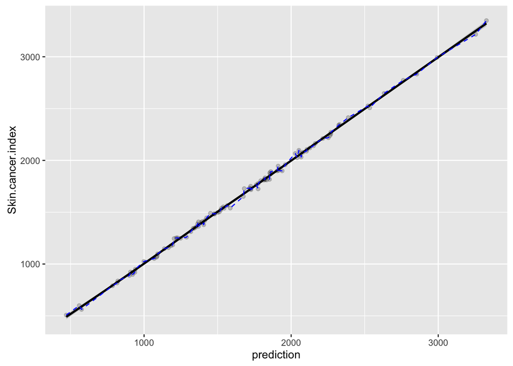

```r
ggplot(data = dfTest, aes(x = prediction, y = Skin.cancer.index)) + geom_point(alpha = 0.2,
    color = "black") + geom_smooth(aes(x = prediction, y = Skin.cancer.index),
    color = "black") + geom_line(aes(x = prediction, y = Skin.cancer.index),
    color = "blue", linetype = 2)
```

From the above we can see that points are not widely scattered from this line - sign of good fit.

We can also plot the residuals where the prediction error $prediction - Skin.cancer.index$ are plotted as a function of $prediction$. In this case the line of perfect prediction is the line y=0.

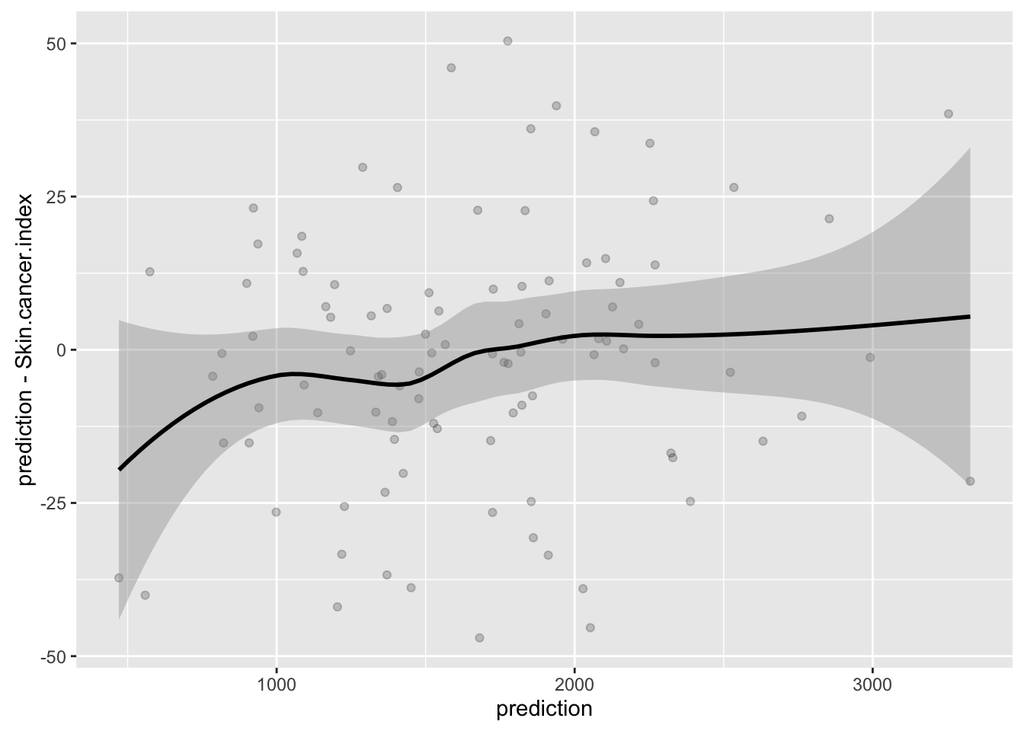

```r
ggplot(data = dfTest, aes(x = prediction, y = prediction - Skin.cancer.index)) +
    geom_point(alpha = 0.2, color = "black") + geom_smooth(aes(x = prediction,
    y = prediction - Skin.cancer.index), color = "black")
```

from the above, we can see that the smoothing curve lie more or less along the line of perfect fit. The points lie close to that line. On an average the model predicts correctly but it underpredicts about at much as it overpredicts.

### Linear Regression Model Characteristics

```r
summary(model)
```

```
##
## Call:
## lm(formula = Skin.cancer.index ~ Exp.to.sun + Usage.sun.screen.lotion,
##     data = dfTrain)
##
## Residuals:
##     Min      1Q  Median      3Q     Max
## -58.689 -14.588   0.381  14.397  77.979
##
## Coefficients:
##                          Estimate Std. Error  t value Pr(>|t|)
## (Intercept)              6.451979   3.505310    1.841    0.066 .
## Exp.to.sun               5.003858   0.006910  724.132   <2e-16 ***
## Usage.sun.screen.lotion -2.000941   0.003393 -589.784   <2e-16 ***
## ---
## Signif. codes:  0 '***' 0.001 '**' 0.01 '*' 0.05 '.' 0.1 ' ' 1
##
## Residual standard error: 20.43 on 897 degrees of freedom
## Multiple R-squared:  0.9988, Adjusted R-squared:  0.9988
## F-statistic: 3.813e+05 on 2 and 897 DF,  p-value: < 2.2e-16
```

### Comparing R-squares in Train and test

```r
rsq <- function(y,f) { 1 - sum( (y-f)^2)/sum((y-mean(y))^2)}
rsq(dfTrain$Skin.cancer.index, predict(model, newdata=dfTrain))
```

```
## [1] 0.998825
```

```r
rsq(dfTest$Skin.cancer.index, predict(model, newdata=dfTest))
```

```
## [1] 0.9986354
```

we want R-Squared to be large (as close to 1) and similar on both test and training. From the result above it is clear that we have similar on both, Had it been high on train and low on test, it would have pointed to over-fitted model

### Residuals summary

In linear regression residuals is everything. Most of what we want to know about the quality of our model fit is in residuals. The residuals are the errors in prediction - $Skin.cancer.index - predict(model, newdata=DfTrain)$. We can find useful summaries of residuals for both test and training set as shown below

```r
summary(dfTrain$Skin.cancer.index - predict(model, newdata=dfTrain))
```

```
##     Min.  1st Qu.   Median     Mean  3rd Qu.     Max.
## -58.6900 -14.5900   0.3812   0.0000  14.4000  77.9800
```

```r
summary(dfTest$Skin.cancer.index - predict(model, newdata=dfTest))
```

```
##    Min. 1st Qu.  Median    Mean 3rd Qu.    Max.
## -50.390 -10.870   0.628   1.476  14.670  47.020
```

Linear regression works by choosing coeeficients to minimize the sum of squares of the residuals. Residuals should be small. What we hope for is the median near 0 and symmetry in 1st and 3rd Quartile. The quantiles are interesting because 1/2 of the training data has residual in this range. If we draw a randoom training sample, the residual will be in this range exactly 1/2 of the time. So we can expect to see prediction errors of these magnitudes using the above model.

### Only one attribute Linear Regression Models

Given strong correlation between the two independent attributes, lets see individually how well they predict the cancer index

```r
summary(lm(dfTrain$Skin.cancer.index ~ dfTrain$Exp.to.sun))
```

```
##
## Call:
## lm(formula = dfTrain$Skin.cancer.index ~ dfTrain$Exp.to.sun)
##
## Residuals:
##      Min       1Q   Median       3Q      Max
## -1352.39  -274.33   -12.44   259.81  1525.88
##
## Coefficients:
##                      Estimate Std. Error t value Pr(>|t|)
## (Intercept)        -489.58123   67.06027  -7.301 6.31e-13 ***
## dfTrain$Exp.to.sun    1.04159    0.03188  32.676  < 2e-16 ***
## ---
## Signif. codes:  0 '***' 0.001 '**' 0.01 '*' 0.05 '.' 0.1 ' ' 1
##
## Residual standard error: 402.6 on 898 degrees of freedom
## Multiple R-squared:  0.5432, Adjusted R-squared:  0.5427
## F-statistic:  1068 on 1 and 898 DF,  p-value: < 2.2e-16
```

```r
summary(lm(dfTrain$Skin.cancer.index ~ dfTrain$Usage.sun.screen.lotion))
```

```
##
## Call:
## lm(formula = dfTrain$Skin.cancer.index ~ dfTrain$Usage.sun.screen.lotion)
##
## Residuals:
##      Min       1Q   Median       3Q      Max
## -1627.73  -337.45   -30.26   323.22  1734.26
##
## Coefficients:
##                                  Estimate Std. Error t value Pr(>|t|)
## (Intercept)                     -20.51181   84.77202  -0.242    0.809
## dfTrain$Usage.sun.screen.lotion   0.38754    0.01921  20.178   <2e-16 ***
## ---
## Signif. codes:  0 '***' 0.001 '**' 0.01 '*' 0.05 '.' 0.1 ' ' 1
##
## Residual standard error: 494.1 on 898 degrees of freedom
## Multiple R-squared:  0.3119, Adjusted R-squared:  0.3112
## F-statistic: 407.1 on 1 and 898 DF,  p-value: < 2.2e-16
```

So we can see

- using only single attribute is no good, as Exposure to sun explains 54% and 31% only
- the residuals have degarded quite a lot in these models

These two individual models do not beat the combined attribute linear model

## Polynomial Regression Model

while it is likely to be a waste of time, lets assume that we argue and see if we can fit a model like $predicted = \beta_0 + \beta_1 x1 + \beta_2 x1^2 + \beta_3 x^3 + \beta_4 y1 + \beta_5 y^2 + \beta_6 y^3$

We can use $poly()$ function in R to model our X1 and X2 variables easily for this exercise.

```r
polymodel <- lm(dfTrain$Skin.cancer.index ~ poly(dfTrain$Exp.to.sun,3) + poly(dfTrain$Usage.sun.screen.lotion, 3))
summary(polymodel)
```

```
##
## Call:
## lm(formula = dfTrain$Skin.cancer.index ~ poly(dfTrain$Exp.to.sun,
##     3) + poly(dfTrain$Usage.sun.screen.lotion, 3))
##
## Residuals:
##     Min      1Q  Median      3Q     Max
## -58.951 -15.187   0.384  14.544  77.977
##
## Coefficients:
##                                             Estimate Std. Error  t value
## (Intercept)                                1.657e+03  6.818e-01 2430.886
## poly(dfTrain$Exp.to.sun, 3)1               6.320e+04  8.781e+01  719.749
## poly(dfTrain$Exp.to.sun, 3)2              -5.681e+01  6.726e+01   -0.845
## poly(dfTrain$Exp.to.sun, 3)3               4.520e+01  5.793e+01    0.780
## poly(dfTrain$Usage.sun.screen.lotion, 3)1 -5.148e+04  8.781e+01 -586.272
## poly(dfTrain$Usage.sun.screen.lotion, 3)2  5.818e+01  6.734e+01    0.864
## poly(dfTrain$Usage.sun.screen.lotion, 3)3 -2.726e+01  5.784e+01   -0.471
##                                           Pr(>|t|)
## (Intercept)                                 <2e-16 ***
## poly(dfTrain$Exp.to.sun, 3)1                <2e-16 ***
## poly(dfTrain$Exp.to.sun, 3)2                 0.399
## poly(dfTrain$Exp.to.sun, 3)3                 0.435
## poly(dfTrain$Usage.sun.screen.lotion, 3)1   <2e-16 ***
## poly(dfTrain$Usage.sun.screen.lotion, 3)2    0.388
## poly(dfTrain$Usage.sun.screen.lotion, 3)3    0.638
## ---
## Signif. codes:  0 '***' 0.001 '**' 0.01 '*' 0.05 '.' 0.1 ' ' 1
##
## Residual standard error: 20.45 on 893 degrees of freedom
## Multiple R-squared:  0.9988, Adjusted R-squared:  0.9988
## F-statistic: 1.268e+05 on 6 and 893 DF,  p-value: < 2.2e-16
```

From the above model it is very clear that

- The R-squared values have not improved from simple linear model
- the **p-values** of the 2nd and 3rd coefficients i.e. $x^2$ $y^2$ $x^3$ $y^3$ are all supporting null hypothesis and should be discarded favouring a linear model itself.

## Final Conclusions

- The Linear Model is able to sufficiently model the Skin Cancer data set
- The polynomial of order 3 does not add any advantage in this data set
- The performance of Linear model in testing data is not different than training data
- Residuals are sufficiently low for Linear model.
- Linear regression model with 2 attributes has lower residuals and better Variance explanation than single attribute models

# Question-2 : Implement Logistic Regression on Cancer Data Set

We are going to be using **Cancer Data set** in this response. Note the following with regards to Logistics Regression. Note that this is Winsconsin Breast Cancer data set where all data is factors (not continous)

- LR is go to technique for binary classification.
- It has trouble dealing with very large number of vriables or categorical variables with large number of levels
- It is well caliberated and reproduces the marginal probabilities of the data
- It can predict well even in presence of correlated variables but correlated variables reduce the quality of advice
- Overly large coefficient magnitudes, overly large std errors on coefficient estimates and wrong sign on a coefficient could be indications of correlated inputs
- glm() in R provides a good diagnostic but rechecking model on test data is still most effective diagnostic

## Reading the dataset

First we read the dataset from file assumed to be present in current directory. Then we analyze if to see whether it has any missing values or not.

```r
setwd("~/")
df <- read.csv(file = "./cancer-data.csv", header = TRUE, sep = ",", na.strings = "?")
# df[] <- lapply(df, factor)
summary(df)
```

```
##    Thickness        Cell.Size        Cell.Shape     Marginal.Adhesion
##  Min.   : 1.000   Min.   : 1.000   Min.   : 1.000   Min.   : 1.000
##  1st Qu.: 2.000   1st Qu.: 1.000   1st Qu.: 1.000   1st Qu.: 1.000
##  Median : 4.000   Median : 1.000   Median : 1.000   Median : 1.000
##  Mean   : 4.418   Mean   : 3.134   Mean   : 3.207   Mean   : 2.807
##  3rd Qu.: 6.000   3rd Qu.: 5.000   3rd Qu.: 5.000   3rd Qu.: 4.000
##  Max.   :10.000   Max.   :10.000   Max.   :10.000   Max.   :10.000
##
##  Single.Epithelial.Cell.Size  Bare.Nuclei     Bland.Chromatin
##  Min.   : 1.000              Min.   : 1.000   Min.   : 1.000
##  1st Qu.: 2.000              1st Qu.: 1.000   1st Qu.: 2.000
##  Median : 2.000              Median : 1.000   Median : 3.000
##  Mean   : 3.216              Mean   : 3.545   Mean   : 3.438
##  3rd Qu.: 4.000              3rd Qu.: 6.000   3rd Qu.: 5.000
##  Max.   :10.000              Max.   :10.000   Max.   :10.000
##                              NA's   :16
##  Normal.Nucleoli     Mitoses            NA.
##  Min.   : 1.000   Min.   : 1.000   Min.   :2.00
##  1st Qu.: 1.000   1st Qu.: 1.000   1st Qu.:2.00
##  Median : 1.000   Median : 1.000   Median :2.00
##  Mean   : 2.867   Mean   : 1.589   Mean   :2.69
##  3rd Qu.: 4.000   3rd Qu.: 1.000   3rd Qu.:4.00
##  Max.   :10.000   Max.   :10.000   Max.   :4.00
##
```

```r
sum(complete.cases(df)) == nrow(df)
```

```
## [1] FALSE
```

```r
df <- df[complete.cases(df), ]
```

we can see this has

- 699 rows in total
- we had missing values so lets use only the ones which are complete which is 683 in number
- we will rename last column to Cancer.Type instead of NA. with 2 presumably meaning Benign and 4 meaning Malignant. Also since there are only two values (Bunary - 2 and 4 ) - we can just convert them to 1 and 0s in additional column and use that for prediction. We use a column called Is.Malignant as this binary column to ease out our work

```r
colnames(df)[10] <- "Cancer.Type"
df <- transform(df, Is.Malignant = ifelse(Cancer.Type == "4", 1, 0))
tail(df)
```

```
##     Thickness Cell.Size Cell.Shape Marginal.Adhesion
## 694         3         1          1                 1
## 695         3         1          1                 1
## 696         2         1          1                 1
## 697         5        10         10                 3
## 698         4         8          6                 4
## 699         4         8          8                 5
##     Single.Epithelial.Cell.Size Bare.Nuclei Bland.Chromatin
## 694                           2           1               2
## 695                           3           2               1
## 696                           2           1               1
## 697                           7           3               8
## 698                           3           4              10
## 699                           4           5              10
##     Normal.Nucleoli Mitoses Cancer.Type Is.Malignant
## 694               1       2           2            0
## 695               1       1           2            0
## 696               1       1           2            0
## 697              10       2           4            1
## 698               6       1           4            1
## 699               4       1           4            1
```

we will split this into two sets for our use with 90% for training and 10% for testing.

```r
df$rgroup <- runif(dim(df)[[1]]) # add a column which is sourced from a random no between 0 and 1
dfTrain <- subset(df, rgroup <= 0.9) # all rows with this column <= 0.9 - get 90% rows
dfTest <- subset(df, rgroup > 0.9) # all rows with column > 0.9 - get 10% rows
```

Just for checking the total number of rows in **dfTrain** is **618** and that of **dfTest** is **65**

### Build the Logistics Regression Model

The command to build the logistics model in R is glm().

```r
model <- glm(Is.Malignant ~ Thickness + Cell.Size + Cell.Shape + Marginal.Adhesion +
    Single.Epithelial.Cell.Size + Bare.Nuclei + Bland.Chromatin + Normal.Nucleoli +
    Mitoses, data = dfTrain, family = binomial(link = "logit"))
```

### Making Predictions

Making the predictions with glm() is similar to lm()

```r
dfTrain$pred <- predict(model, newdata = dfTrain, type = "response")
dfTest$pred <- predict(model, newdata = dfTest, type = "response")
```

Note the additional parameter response = this tells predict that you need to return the probabilies y. If we do not give this, it will return the outut of link() function logit(y)

### Characterizing Prediction Quality

On the training set we plot distribution of prediction score grouped by known outcome.

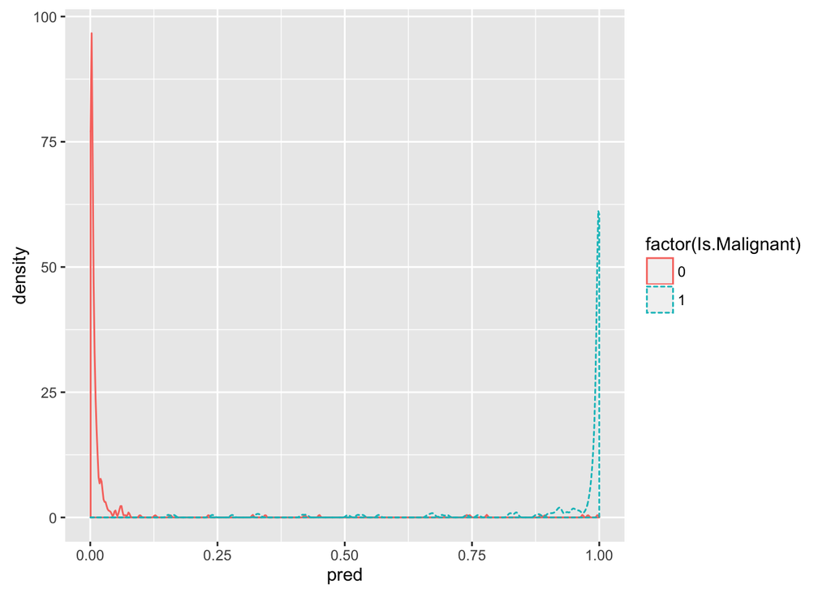

```r
ggplot(dfTrain, aes(x=pred, color=factor(Is.Malignant), linetype=factor(Is.Malignant))) + geom_density()
```

```r
ctab.test <- table(pred=dfTest$pred > 0.040, Is.Malignant=ifelse(dfTest$Is.Malignant == 1, TRUE, FALSE))
ctab.test
```

```
##        Is.Malignant
## pred    FALSE TRUE
##   FALSE    36    1
##   TRUE      1   27
```

```r
precision <- ctab.test[2,2]/sum(ctab.test[2,])
precision
```

```
## [1] 0.9642857
```

```r
recall <- ctab.test[2,2]/sum(ctab.test[,2])
recall
```

```
## [1] 0.9642857
```

Our model has good recall and precision at the same time.

## Reading the Model summary

```r
summary(model)
```

```
##
## Call:
## glm(formula = Is.Malignant ~ Thickness + Cell.Size + Cell.Shape +
##     Marginal.Adhesion + Single.Epithelial.Cell.Size + Bare.Nuclei +
##     Bland.Chromatin + Normal.Nucleoli + Mitoses, family = binomial(link = "logit"),
##     data = dfTrain)
##
## Deviance Residuals:
##     Min       1Q   Median       3Q      Max
## -3.4018  -0.1104  -0.0588   0.0206   1.9372
##
## Coefficients:
##                              Estimate Std. Error z value Pr(>|z|)
## (Intercept)                 -10.04057    1.24825  -8.044 8.71e-16 ***
## Thickness                     0.50905    0.14730   3.456 0.000548 ***
## Cell.Size                     0.07965    0.23786   0.335 0.737723
## Cell.Shape                    0.43106    0.25701   1.677 0.093505 .
## Marginal.Adhesion             0.27064    0.12878   2.102 0.035596 *
## Single.Epithelial.Cell.Size   0.06946    0.16227   0.428 0.668616
## Bare.Nuclei                   0.35251    0.09653   3.652 0.000260 ***
## Bland.Chromatin               0.39827    0.18620   2.139 0.032443 *
## Normal.Nucleoli               0.23934    0.11895   2.012 0.044210 *
## Mitoses                       0.45359    0.35882   1.264 0.206191
## ---
## Signif. codes:  0 '***' 0.001 '**' 0.01 '*' 0.05 '.' 0.1 ' ' 1
##
## (Dispersion parameter for binomial family taken to be 1)
##
##     Null deviance: 793.48  on 617  degrees of freedom
## Residual deviance:  91.70  on 608  degrees of freedom
## AIC: 111.7
##
## Number of Fisher Scoring iterations: 8
```

### Deviance Residuals summary

Deviance residuals are linked to the log likelihood of having observed the true outcome, given the predicted probability of that outcome.

### Coefficients

The coefficient of logistic regression model encode the relationships between the input variables and the output variables in a way similar to how the coefficients of a linear regression model do.

Negative coefficients that are statistically significant correspond to variables that are negatively correlated to the odds (and hence probability) of a positive outcome (i.e. Cancer is Malignant). Positive coefficients that are statistically significant are positively correlated to the odds of positive outcome.

#### Converting to Factors and reruning the whole show

```r
setwd("~/")
df <- read.csv(file = "./cancer-data.csv", header = TRUE, sep = ",", na.strings = "?")
df[] <- lapply(df, factor)
summary(df)
```

```
##    Thickness     Cell.Size     Cell.Shape  Marginal.Adhesion
##  1      :145   1      :384   1      :353   1      :407
##  5      :130   10     : 67   2      : 59   2      : 58
##  3      :108   3      : 52   10     : 58   3      : 58
##  4      : 80   2      : 45   3      : 56   10     : 55
##  10     : 69   4      : 40   4      : 44   4      : 33
##  2      : 50   5      : 30   5      : 34   8      : 25
##  (Other):117   (Other): 81   (Other): 95   (Other): 63
##  Single.Epithelial.Cell.Size  Bare.Nuclei  Bland.Chromatin Normal.Nucleoli
##  2      :386                 1      :402   2      :166     1      :443
##  3      : 72                 10     :132   3      :165     10     : 61
##  4      : 48                 2      : 30   1      :152     3      : 44
##  1      : 47                 5      : 30   7      : 73     2      : 36
##  6      : 41                 3      : 28   4      : 40     8      : 24
##  5      : 39                 (Other): 61   5      : 34     6      : 22
##  (Other): 66                 NA's   : 16   (Other): 69     (Other): 69
##     Mitoses    NA.
##  1      :579   2:458
##  2      : 35   4:241
##  3      : 33
##  10     : 14
##  4      : 12
##  7      :  9
##  (Other): 17
```

```r
sum(complete.cases(df)) == nrow(df)
```

```
## [1] FALSE
```

```r
df <- df[complete.cases(df), ]
colnames(df)[10] <- "Cancer.Type"
df <- transform(df, Is.Malignant = ifelse(Cancer.Type == "4", 1, 0))
tail(df)
```

```
##     Thickness Cell.Size Cell.Shape Marginal.Adhesion
## 694         3         1          1                 1
## 695         3         1          1                 1
## 696         2         1          1                 1
## 697         5        10         10                 3
## 698         4         8          6                 4
## 699         4         8          8                 5
##     Single.Epithelial.Cell.Size Bare.Nuclei Bland.Chromatin
## 694                           2           1               2
## 695                           3           2               1
## 696                           2           1               1
## 697                           7           3               8
## 698                           3           4              10
## 699                           4           5              10
##     Normal.Nucleoli Mitoses Cancer.Type Is.Malignant
## 694               1       2           2            0
## 695               1       1           2            0
## 696               1       1           2            0
## 697              10       2           4            1
## 698               6       1           4            1
## 699               4       1           4            1
```

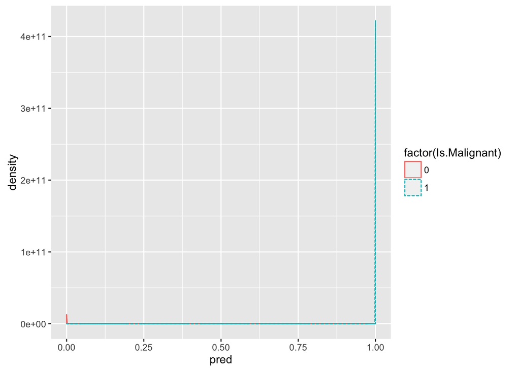

```r
df$rgroup <- runif(dim(df)[[1]])  # add a column which is sourced from a random no between 0 and 1
dfTrain <- subset(df, rgroup <= 0.9)  # all rows with this column <= 0.9 - get 90% rows
dfTest <- subset(df, rgroup > 0.9)  # all rows with column > 0.9 - get 10% rows
model <- glm(Is.Malignant ~ Thickness + Cell.Size + Cell.Shape + Marginal.Adhesion +
    Single.Epithelial.Cell.Size + Bare.Nuclei + Bland.Chromatin + Normal.Nucleoli +
    Mitoses, data = dfTrain, family = binomial(link = "logit"))
dfTrain$pred <- predict(model, newdata = dfTrain, type = "response")
dfTest$pred <- predict(model, newdata = dfTest, type = "response")
ggplot(dfTrain, aes(x = pred, color = factor(Is.Malignant), linetype = factor(Is.Malignant))) +
    geom_density()
```

```r
ctab.test <- table(pred = dfTest$pred > 0.04, Is.Malignant = ifelse(dfTest$Is.Malignant ==
    1, TRUE, FALSE))
ctab.test
```

```
##        Is.Malignant
## pred    FALSE TRUE
##   FALSE    33    6
##   TRUE      0   22
```

```r
precision <- ctab.test[2, 2]/sum(ctab.test[2, ])
precision
```

```
## [1] 1
```

```r
recall <- ctab.test[2, 2]/sum(ctab.test[, 2])
recall
```

```
## [1] 0.7857143
```

```r
summary(model)
```

```
##
## Call:
## glm(formula = Is.Malignant ~ Thickness + Cell.Size + Cell.Shape +
##     Marginal.Adhesion + Single.Epithelial.Cell.Size + Bare.Nuclei +
##     Bland.Chromatin + Normal.Nucleoli + Mitoses, family = binomial(link = "logit"),
##     data = dfTrain)
##
## Deviance Residuals:
##        Min          1Q      Median          3Q         Max
## -4.562e-05  -2.100e-08  -2.100e-08   2.100e-08   5.063e-05
##
## Coefficients:
##                                 Estimate Std. Error z value Pr(>|z|)
## (Intercept)                   -8.477e+01  1.964e+05   0.000    1.000
## Thickness2                     1.759e+01  1.092e+05   0.000    1.000
## Thickness3                     3.243e+00  1.232e+05   0.000    1.000
## Thickness4                     1.535e+01  7.334e+04   0.000    1.000
## Thickness5                     4.083e+00  8.584e+04   0.000    1.000
## Thickness6                    -2.106e+01  1.393e+05   0.000    1.000
## Thickness7                     7.107e+01  1.141e+05   0.001    1.000
## Thickness8                     2.406e+01  1.358e+05   0.000    1.000
## Thickness9                     1.032e+02  2.223e+05   0.000    1.000
## Thickness10                    8.019e+01  1.419e+05   0.001    1.000
## Cell.Size2                     1.410e+01  7.170e+04   0.000    1.000
## Cell.Size3                     3.088e+01  5.272e+04   0.001    1.000
## Cell.Size4                    -6.441e-01  9.104e+04   0.000    1.000
## Cell.Size5                     2.518e+01  2.478e+05   0.000    1.000
## Cell.Size6                     5.316e+01  2.606e+05   0.000    1.000
## Cell.Size7                    -3.778e+00  2.346e+05   0.000    1.000
## Cell.Size8                     6.088e+01  3.167e+05   0.000    1.000
## Cell.Size9                     1.106e+02  1.720e+05   0.001    0.999
## Cell.Size10                    9.212e+01  2.302e+05   0.000    1.000
## Cell.Shape2                   -3.533e+01  1.471e+05   0.000    1.000
## Cell.Shape3                    1.579e+01  7.935e+04   0.000    1.000
## Cell.Shape4                    5.152e+00  6.342e+04   0.000    1.000
## Cell.Shape5                    1.533e+01  9.931e+04   0.000    1.000
## Cell.Shape6                   -9.559e+00  2.072e+05   0.000    1.000
## Cell.Shape7                   -5.076e+01  1.741e+05   0.000    1.000
## Cell.Shape8                    1.037e+01  2.303e+05   0.000    1.000
## Cell.Shape9                    5.059e+01  2.838e+05   0.000    1.000
```

[output cut: 47 more lines]

```
## Mitoses3                       2.534e+01  1.189e+05   0.000    1.000
## Mitoses4                       6.033e-01  6.791e+05   0.000    1.000
## Mitoses5                      -7.645e+01  3.133e+05   0.000    1.000
## Mitoses6                      -1.470e+02  2.480e+05  -0.001    1.000
## Mitoses7                       3.241e+01  1.840e+05   0.000    1.000
## Mitoses8                      -5.669e+01  2.485e+05   0.000    1.000
## Mitoses10                      3.095e+01  2.207e+05   0.000    1.000
##
## (Dispersion parameter for binomial family taken to be 1)
##
##     Null deviance: 7.9681e+02  on 621  degrees of freedom
## Residual deviance: 3.7488e-08  on 541  degrees of freedom
## AIC: 162
##
## Number of Fisher Scoring iterations: 25
```

As is obvious from summary stats, this model is no good - it has very large number of iterations and not a single attribute which is beating the Null Hypothesis.

# Question-3 : Time series analysis for NY Birth Data

## Reading the dataset

First we read the dataset from file assumed to be present in current directory.

```r
setwd("~/")
df <- read.csv(file = "NYbirths.txt", header = FALSE, sep = ",")
summary(df)
```

```
##        V1
##  Min.   :20.00
##  1st Qu.:23.28
##  Median :24.96
##  Mean   :25.06
##  3rd Qu.:26.88
##  Max.   :30.00
```

```r
dim(df)
```

```
## [1] 168   1
```

Given that this starting from January 1946, we can now use ts() object in R

```r
df <- ts(df, frequency = 12, start = c(1946, 1))
df
```

```
##         Jan    Feb    Mar    Apr    May    Jun    Jul    Aug    Sep    Oct
## 1946 26.663 23.598 26.931 24.740 25.806 24.364 24.477 23.901 23.175 23.227
## 1947 21.439 21.089 23.709 21.669 21.752 20.761 23.479 23.824 23.105 23.110
## 1948 21.937 20.035 23.590 21.672 22.222 22.123 23.950 23.504 22.238 23.142
## 1949 21.548 20.000 22.424 20.615 21.761 22.874 24.104 23.748 23.262 22.907
## 1950 22.604 20.894 24.677 23.673 25.320 23.583 24.671 24.454 24.122 24.252
## 1951 23.287 23.049 25.076 24.037 24.430 24.667 26.451 25.618 25.014 25.110
## 1952 23.798 22.270 24.775 22.646 23.988 24.737 26.276 25.816 25.210 25.199
## 1953 24.364 22.644 25.565 24.062 25.431 24.635 27.009 26.606 26.268 26.462
## 1954 24.657 23.304 26.982 26.199 27.210 26.122 26.706 26.878 26.152 26.379
## 1955 24.990 24.239 26.721 23.475 24.767 26.219 28.361 28.599 27.914 27.784
## 1956 26.217 24.218 27.914 26.975 28.527 27.139 28.982 28.169 28.056 29.136
## 1957 26.589 24.848 27.543 26.896 28.878 27.390 28.065 28.141 29.048 28.484
## 1958 27.132 24.924 28.963 26.589 27.931 28.009 29.229 28.759 28.405 27.945
## 1959 26.076 25.286 27.660 25.951 26.398 25.565 28.865 30.000 29.261 29.012
##         Nov    Dec
## 1946 21.672 21.870
## 1947 21.759 22.073
## 1948 21.059 21.573
## 1949 21.519 22.025
## 1950 22.084 22.991
## 1951 22.964 23.981
## 1952 23.162 24.707
## 1953 25.246 25.180
## 1954 24.712 25.688
## 1955 25.693 26.881
## 1956 26.291 26.987
## 1957 26.634 27.735
## 1958 25.912 26.619
## 1959 26.992 27.897
```

## Plot of Basic Time series

Next we plot the time series to understand what components it it likely to have from Trend, Cyclic, Seasonal and Irregular.

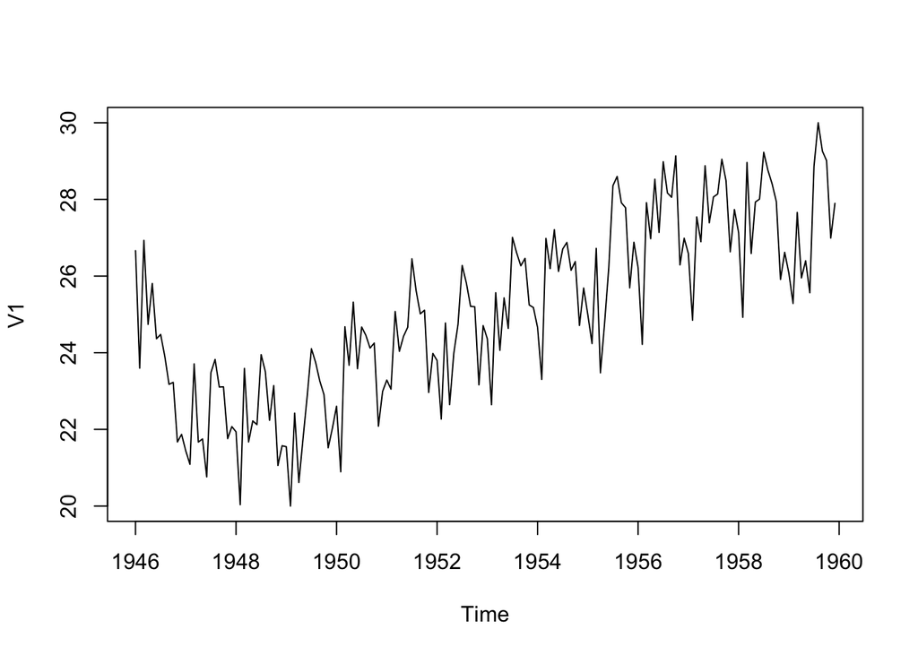

```r
plot.ts(df)
```

There is certainly some seasonal variation in the number of births per month; there is a peak every summer, and a trough every winter. Again the it seems like this could be described using an additive model, as the seasonal fluctuations are roughly constant in size over time and do not seem to depend on the level of the time series, and the random fluctuations seem constant over time.

## Decomposing the time series

A seasonal time series, in addition to the trend and random components, also has a seasonal component. Decomposing a seasonal time series means separating the time series into these three components. In R we can use the decompose() function to estimate the three components of the time series. Lets estimate the trend, seasonal, and random components of the New York births dataset.

```r
dfdecomposed <- decompose(df)
dfdecomposed
```

```
## $x
##         Jan    Feb    Mar    Apr    May    Jun    Jul    Aug    Sep    Oct
## 1946 26.663 23.598 26.931 24.740 25.806 24.364 24.477 23.901 23.175 23.227
## 1947 21.439 21.089 23.709 21.669 21.752 20.761 23.479 23.824 23.105 23.110
## 1948 21.937 20.035 23.590 21.672 22.222 22.123 23.950 23.504 22.238 23.142
## 1949 21.548 20.000 22.424 20.615 21.761 22.874 24.104 23.748 23.262 22.907
## 1950 22.604 20.894 24.677 23.673 25.320 23.583 24.671 24.454 24.122 24.252
## 1951 23.287 23.049 25.076 24.037 24.430 24.667 26.451 25.618 25.014 25.110
## 1952 23.798 22.270 24.775 22.646 23.988 24.737 26.276 25.816 25.210 25.199
## 1953 24.364 22.644 25.565 24.062 25.431 24.635 27.009 26.606 26.268 26.462
## 1954 24.657 23.304 26.982 26.199 27.210 26.122 26.706 26.878 26.152 26.379
## 1955 24.990 24.239 26.721 23.475 24.767 26.219 28.361 28.599 27.914 27.784
## 1956 26.217 24.218 27.914 26.975 28.527 27.139 28.982 28.169 28.056 29.136
## 1957 26.589 24.848 27.543 26.896 28.878 27.390 28.065 28.141 29.048 28.484
## 1958 27.132 24.924 28.963 26.589 27.931 28.009 29.229 28.759 28.405 27.945
```

[output cut: 137 more lines]

we can plot these as well by various components

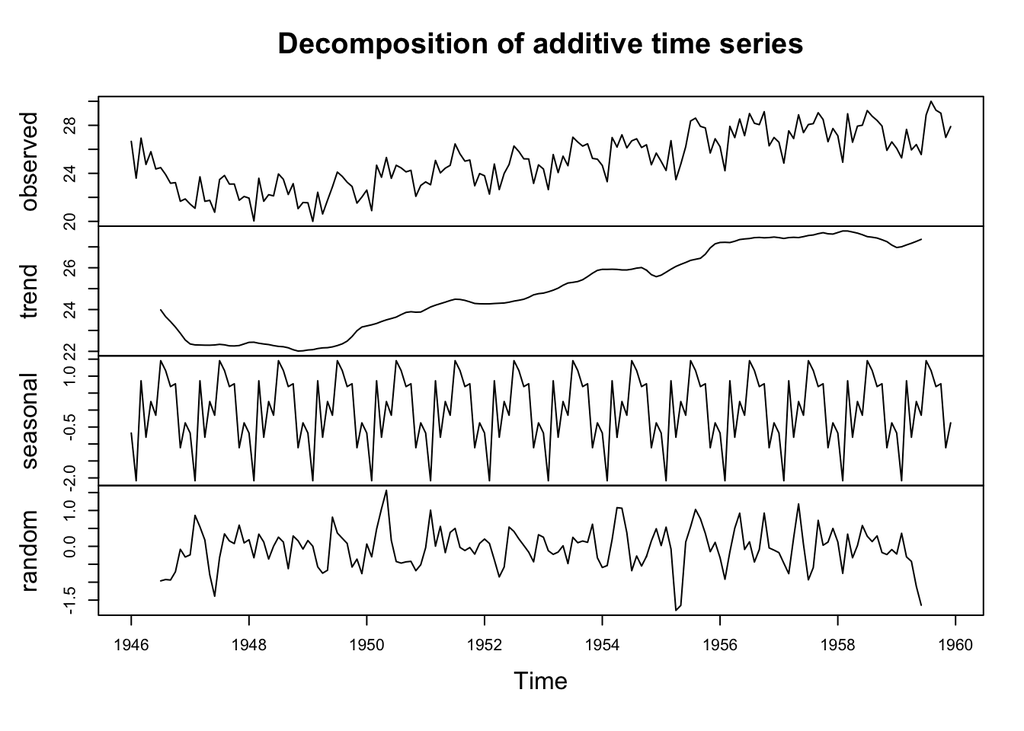

```r
plot(dfdecomposed)
```

### Seasonal Adjustment

If you have a seasonal time series, you can seasonally adjust the series by estimating the seasonal component, and subtracting it from the original time series. We can see below that time time series simply consists of the trend and random components.

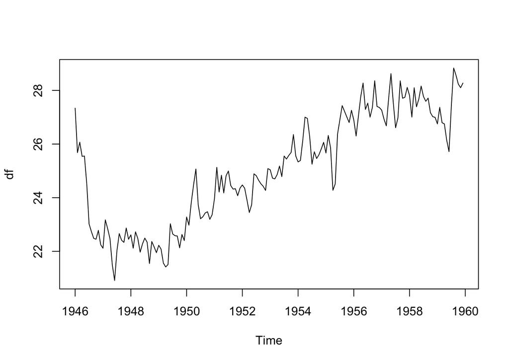

```r
plot.ts(df - dfdecomposed$seasonal)
```

### Trend Adjustment

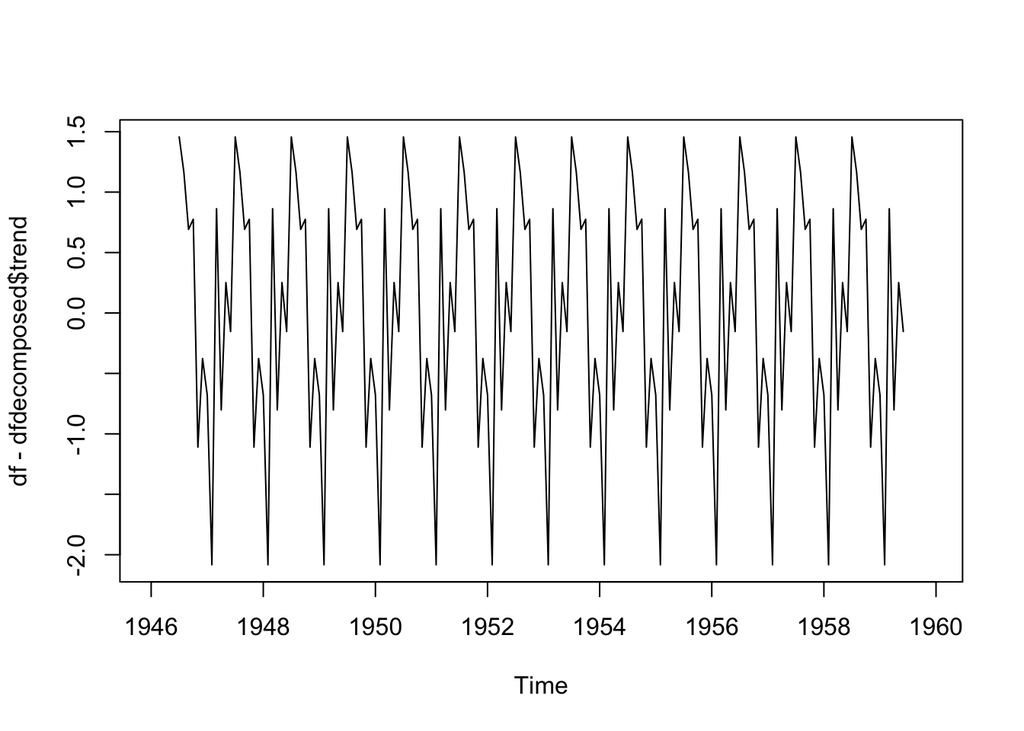

```r
plot.ts(df - dfdecomposed$trend - dfdecomposed$random)
```